# Analysis of Phage Display Protease and Supernatant Screens

# Data from EPIC Results: all neutrophil serine proteases (profile 2)

## EPIC: Generation of Figures for Percentages

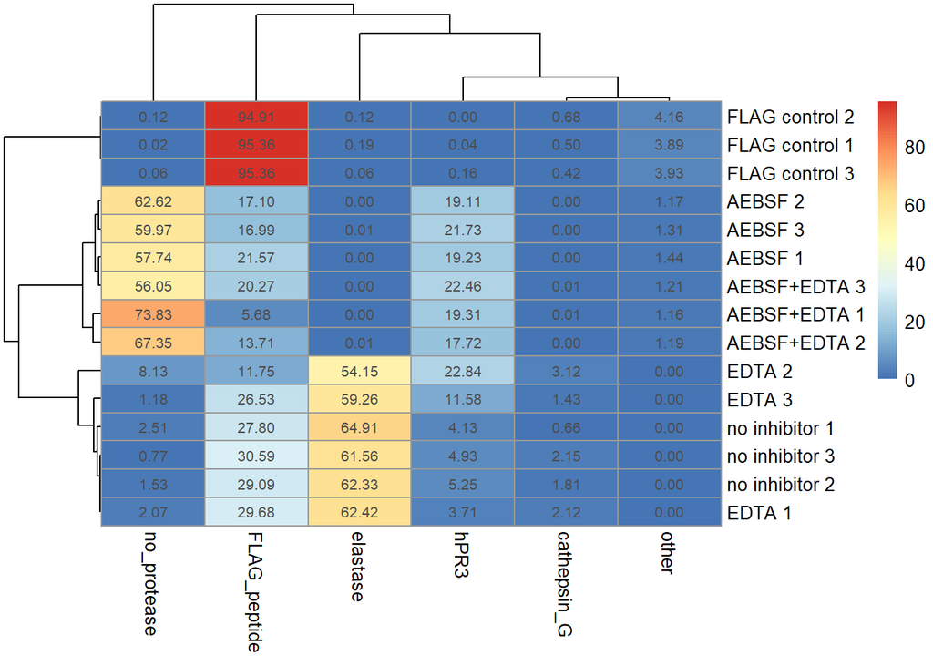

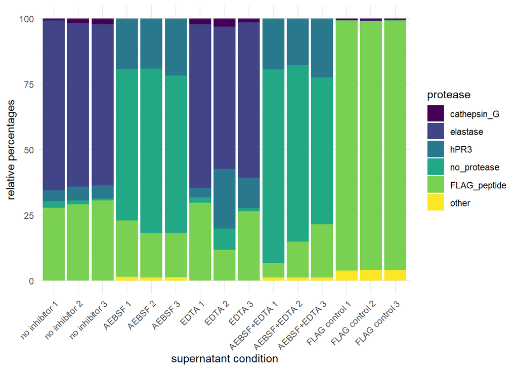

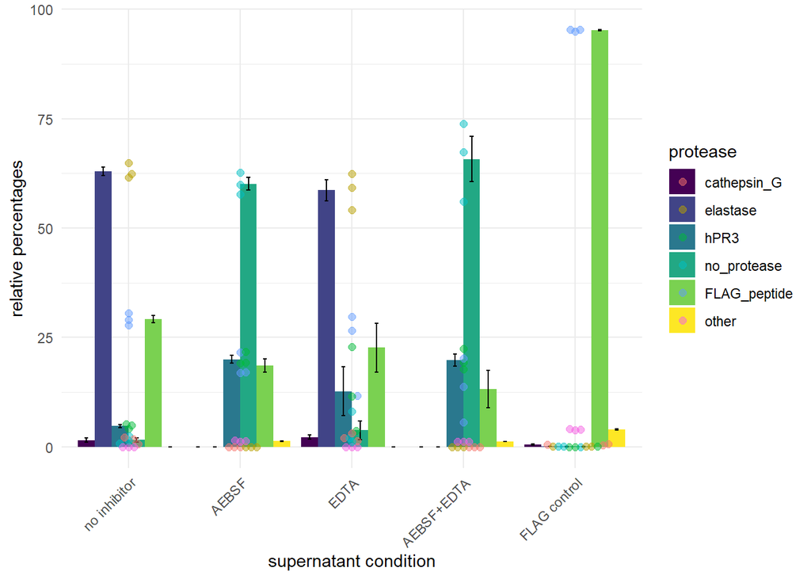

### Statistical Comparisons

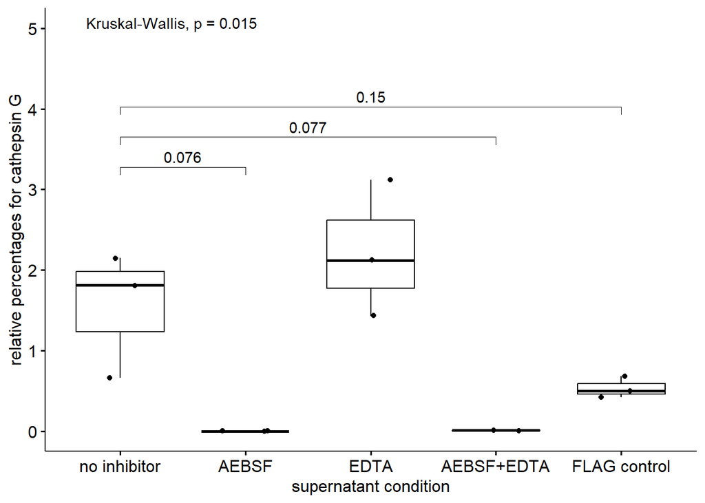

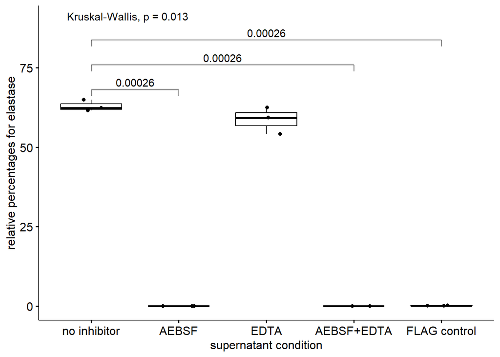

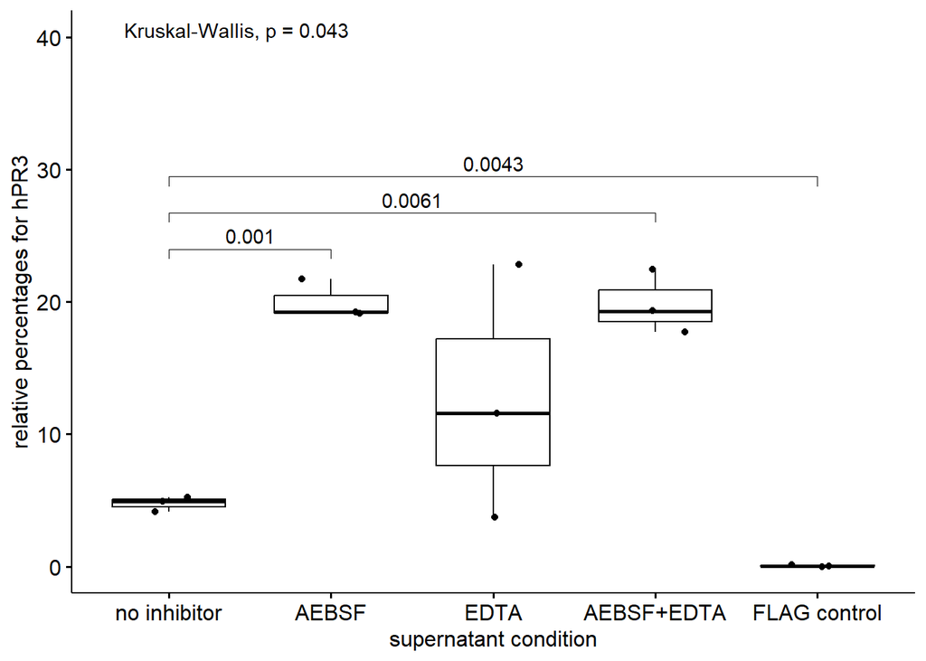

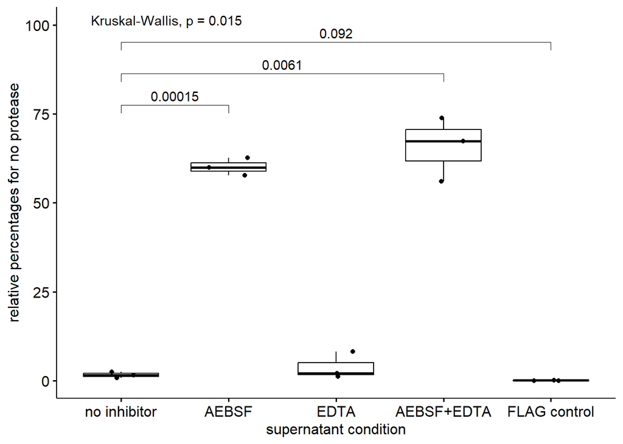

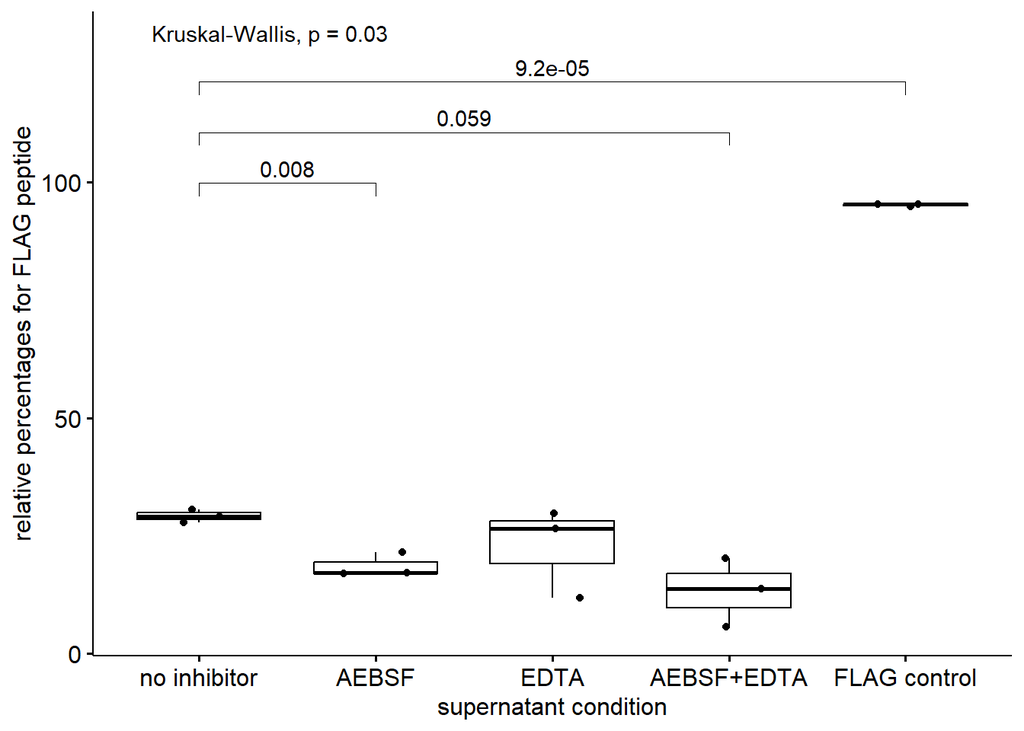

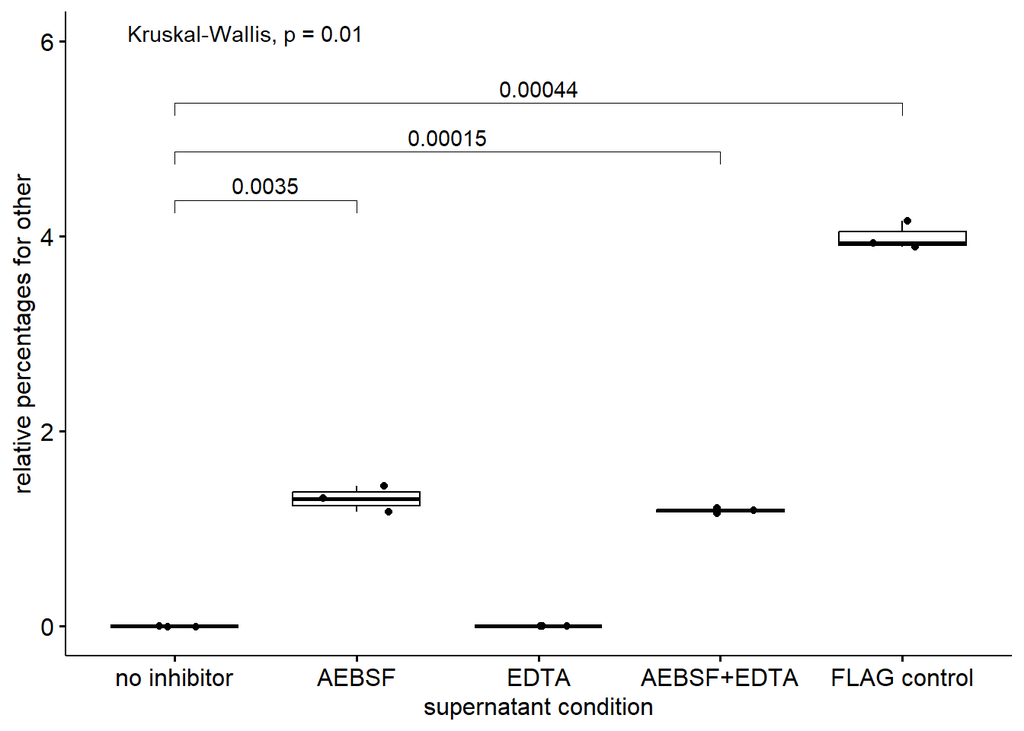

# Data from CibersortX Results: cathepsin G and elastase (profile 3)

Analyses from previously were repeated.

## CibersortX: Generation of Figures for Percentages

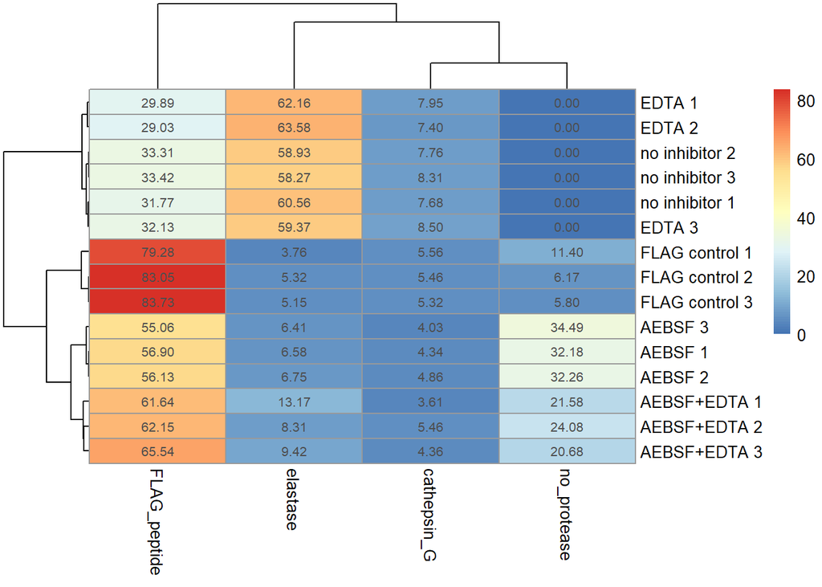

```r
percentage_data <- cibersort_percentage_nohPR3 %>%
  mutate(Condition = paste0(Condition, " ", (row_number()-1)%%3 + 1))
rownames(percentage_data) <- percentage_data[, 1]
heatmap_data <- percentage_data[, -1]
pheatmap(heatmap_data, display_numbers = TRUE)
```

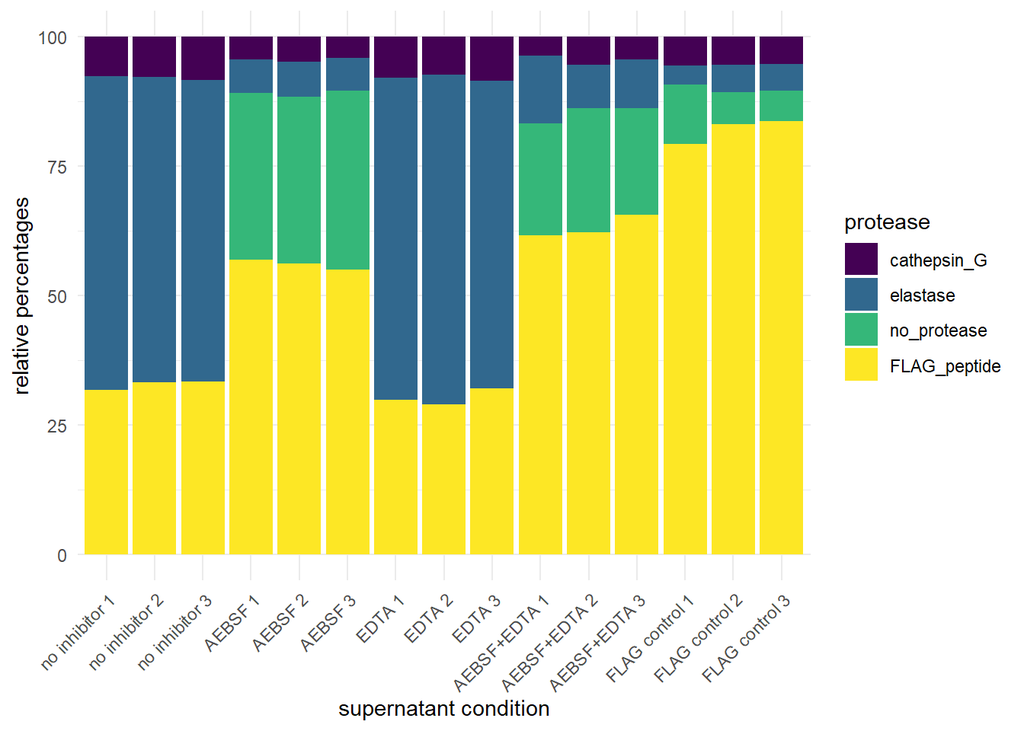

```r
barplot_data <- reshape2::melt(percentage_data, id.vars = "Condition")
ggplot(barplot_data, aes(x = fct_inorder(Condition), y = value, fill = variable)) + geom_bar(stat = "identity") + labs(x = "supernatant condition", y = "relative percentages", fill = "protease") + scale_fill_viridis_d()+ theme_minimal() + theme(axis.text.x = element_text(angle = 45, hjust = 1))
```

## CibersortX: Generation of Figures for Absolute Scores

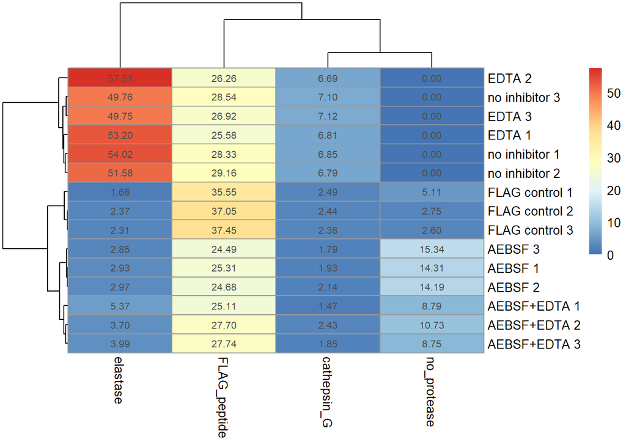

```r
absolute_data <- cibersort_absolute_nohPR3 %>%
  mutate(Condition = paste0(Condition, " ", (row_number()-1)%%3 + 1))
barplot_data <- reshape2::melt(absolute_data, id.vars = "Condition")
rownames(absolute_data) <- absolute_data[, 1]
pheatmap(absolute_data[,-1], display_numbers = TRUE)
```

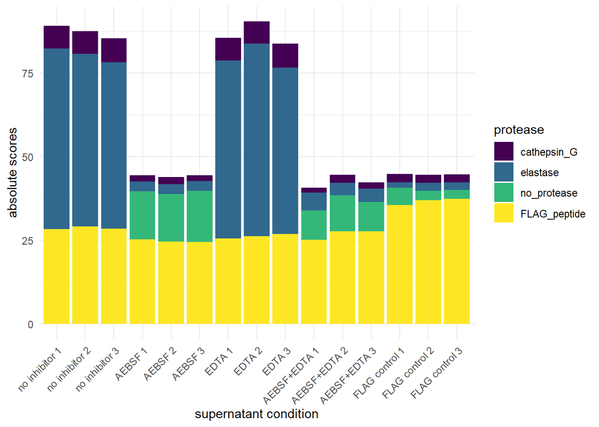

```r
ggplot(barplot_data, aes(x = fct_inorder(Condition), y = value, fill = variable)) + geom_bar(stat = "identity") + labs(x = "supernatant condition", y = "absolute scores", fill = "protease") + scale_fill_viridis_d()+ theme_minimal() + theme(axis.text.x = element_text(angle = 45, hjust = 1))
```

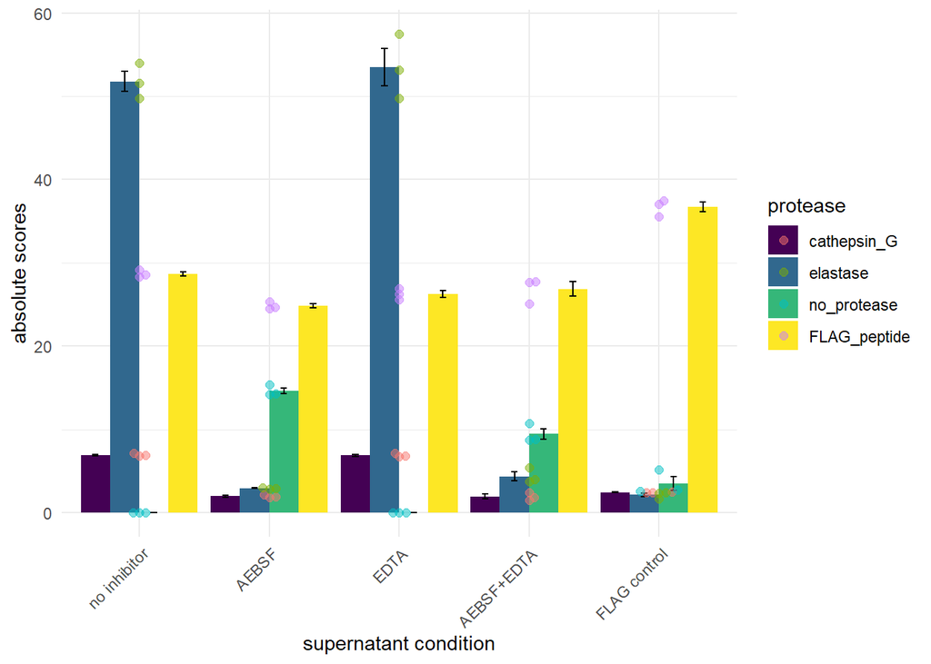

```r
barplot_data <- cibersort_absolute_nohPR3 %>%
  pivot_longer(-Condition, names_to = "protease", values_to = "Absolute_Score")
barplot_data <- barplot_data %>%
  mutate(protease = factor(protease, levels = c("cathepsin_G", "elastase", "no_protease", "FLAG_peptide")))
ggplot(barplot_data, aes(x = fct_inorder(Condition), y = Absolute_Score, fill = protease)) +
  geom_bar(stat = "summary", fun = "mean", position = position_dodge(width = 0.9)) +
  geom_errorbar(stat = "summary", fun.data = "mean_se", width = 0.2, position = position_dodge(width = 0.9)) +
  theme_minimal() +
  labs(x = "supernatant condition", y = "absolute scores", fill = "protease") +
  scale_fill_viridis_d() +
  theme(axis.text.x = element_text(angle = 45, hjust = 1)) +
  geom_beeswarm(data = barplot_data, aes(color = protease), size = 2, alpha = 0.5, position = position_dodge(width = 0.9))
```

### Statistical Comparisons

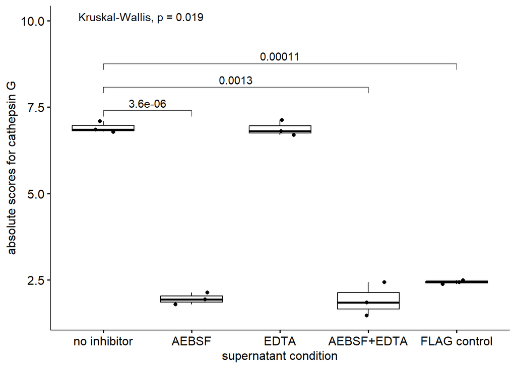

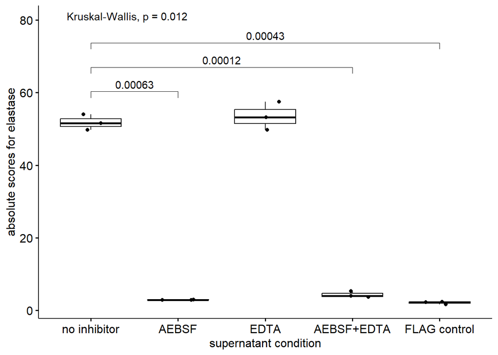

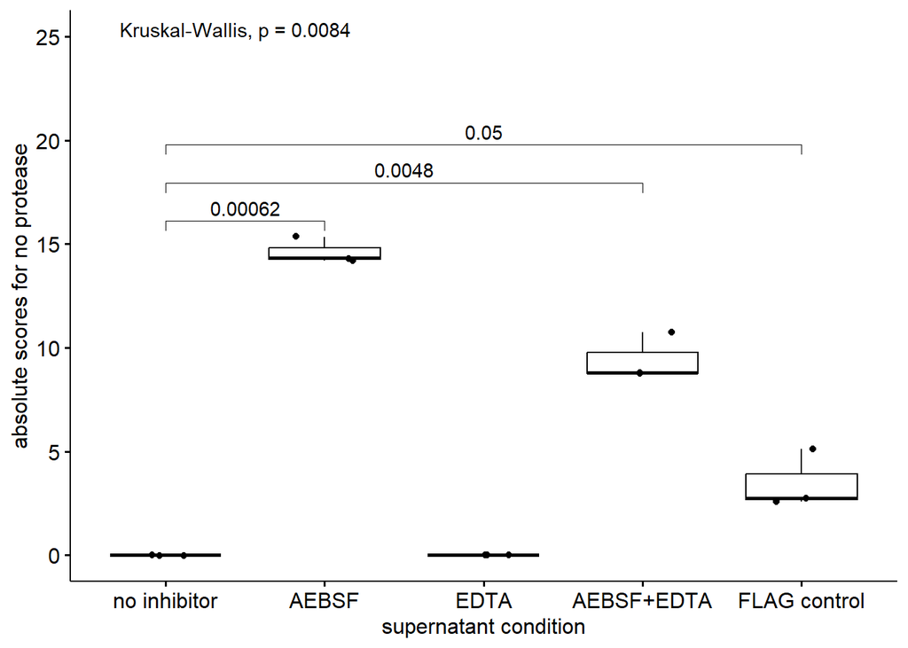

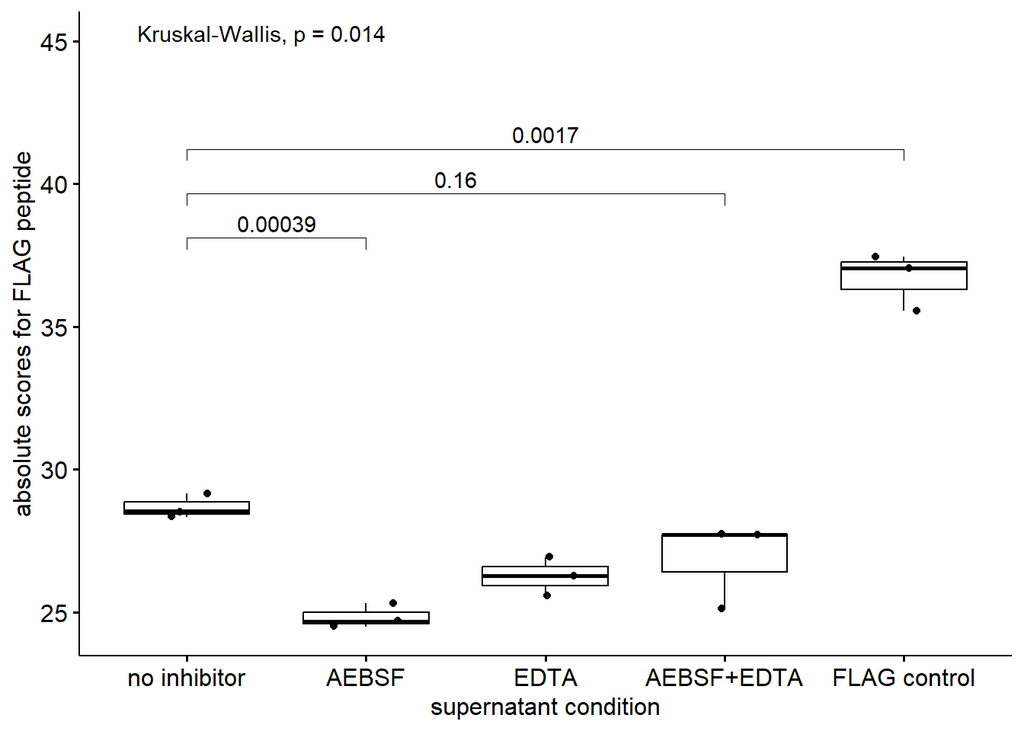

```r
conditions <- c("cathepsin_G", "elastase", "no_protease", "FLAG_peptide")
names = c("cathepsin G", "elastase","no protease", "FLAG peptide")
condition_comparisons <- list( c("no inhibitor", "AEBSF"), c("no inhibitor", "AEBSF+EDTA"), c("no inhibitor", "FLAG control") )
graph_scale = c(10, 80, 25, 45) #scale graph to fit y-axis

for(i in 1:length(conditions)){
  box_plot <-ggboxplot(cibersort_absolute_nohPR3, x = "Condition", y = conditions[i], add = "jitter") +
  labs(x = "supernatant condition", y = paste0("absolute scores for ", names[i])) +
  stat_compare_means(comparisons = condition_comparisons, method = "t.test") +
  stat_compare_means(label.y = graph_scale[i])
  show(box_plot)
}
```

# Data from EPIC Results: cathepsin G and elastase (profile 3)

## EPIC: Generation of Figures for Percentages

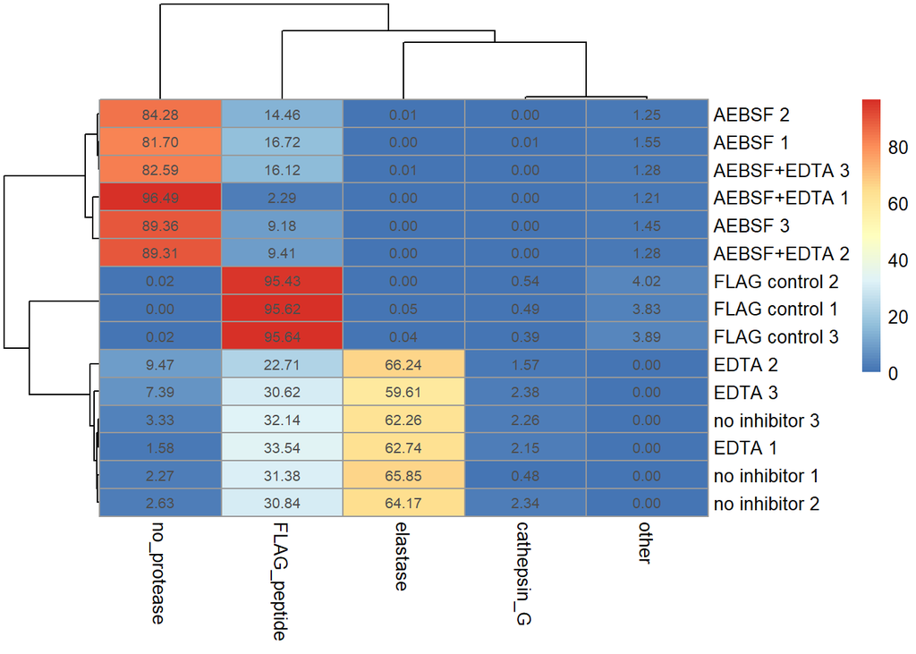

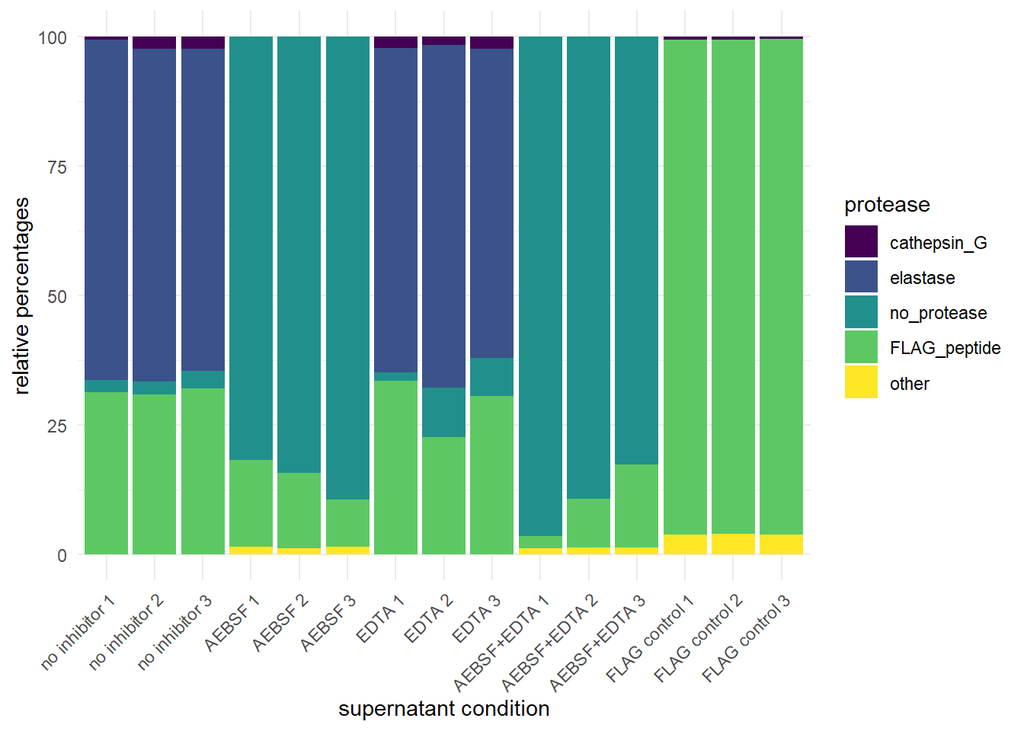

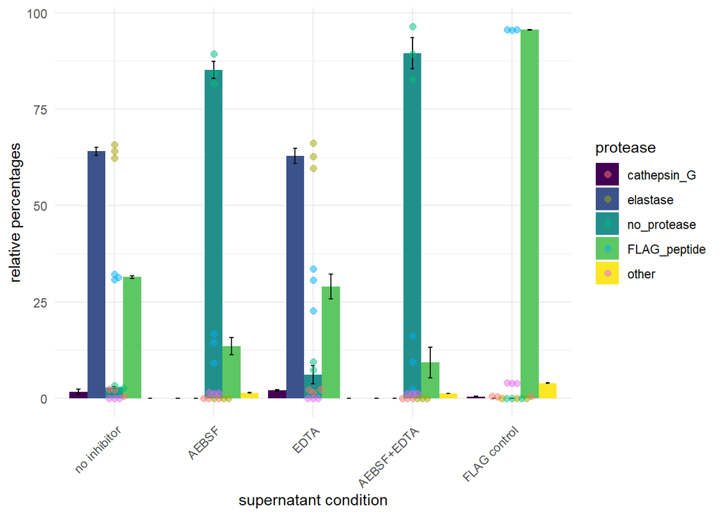

### Statistical Comparisons

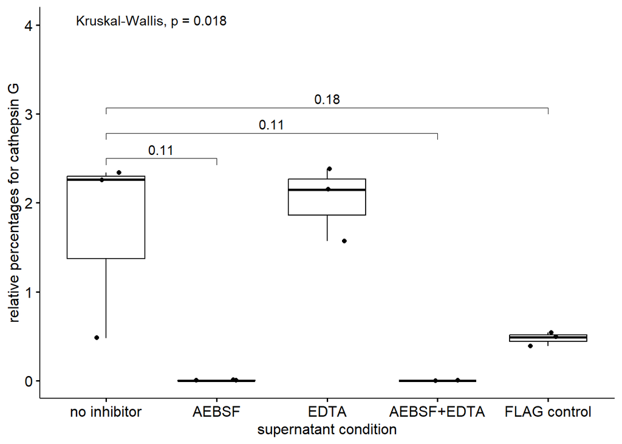

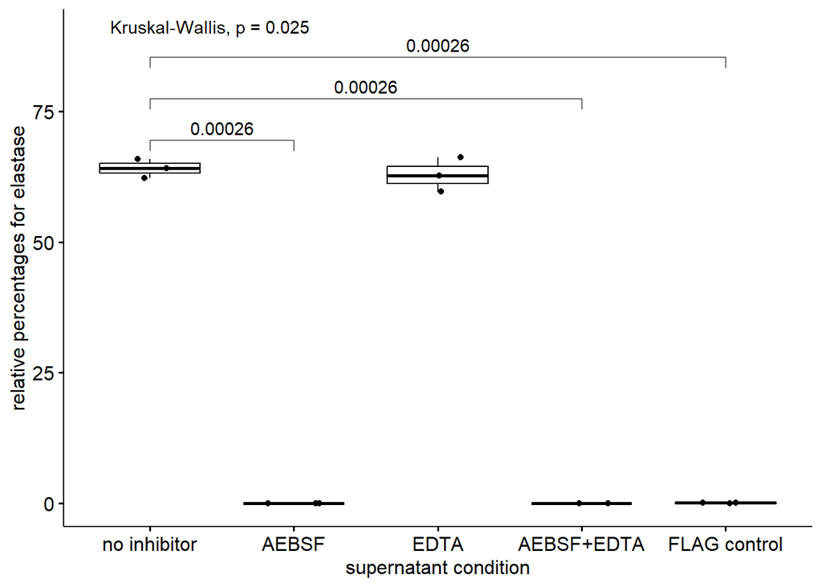

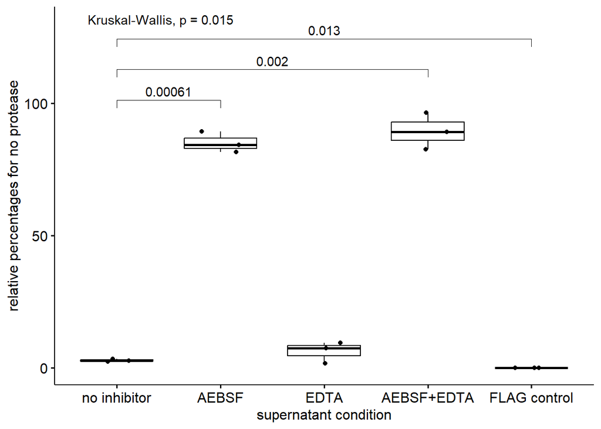

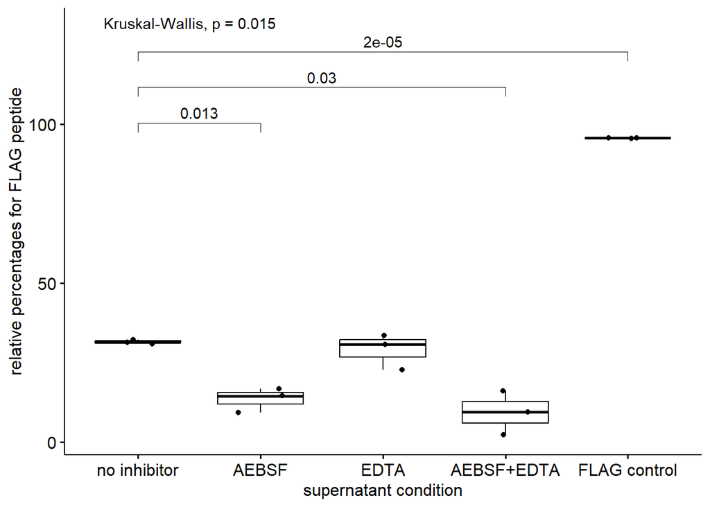

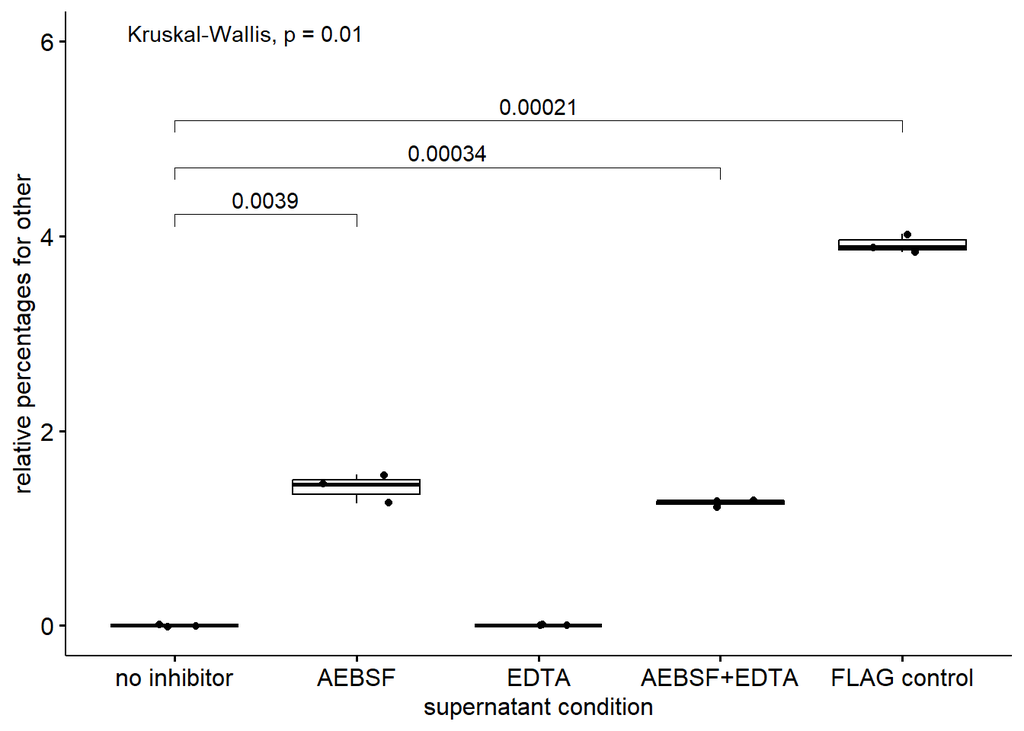

# Comparison to MEROPs Database

The MEROPs database consists of known substrates for individual proteases, like neutrophil serine proteases, based on prior studies and screens. To validate the current dataset towards known substrates of proteases, its cleaved peptides were compared to those of MEROPs.

MEROPs substrates (8-mers) were obtained and converted into 5-mer or 4-mer space, which were subsequently compared with the significantly cleaved peptides of cathepsin G, elastase, and hPR3.

```r
convert_3_to_1 <- function(three_letter_code) {
  codes <- c(
    Ala = "A", Arg = "R", Asn = "N", Asp = "D", Cys = "C",
    Gln = "Q", Glu = "E", Gly = "G", His = "H", Ile = "I",
    Leu = "L", Lys = "K", Met = "M", Phe = "F", Pro = "P",
    Ser = "S", Thr = "T", Trp = "W", Tyr = "Y", Val = "V"
  )
  if(is.na(codes[three_letter_code])){
    return("-")
  } else{
    return(codes[three_letter_code])
  }
}
```

## Splitting of MEROPs 8-mers into 5-mers/4-mers

A MEROPs database list of substrates was obtained for each of the 3 neutrophil serine proteases: cathepsin G, neutrophil elastase, and human proteinase 3. Tables were derived and 5-mers/4-mers were compiled for each 8-mer substrate. Only 5-mers/4-mers with natural amino acids were included for analysis.

```r
meropsList <- list()
meropsList_4mer <- list()
combined <- append(proteases, mixtures)

for(i in 1:3){
  meropsData <- read.xlsx(paste0(combined[i], "_MEROPs.xlsx"))
  aminoacidMerops <- meropsData[7:14]
  colnames(aminoacidMerops) <- c("P4",  "P3",  "P2",  "P1", "P1x", "P2x", "P3x","P4x")
  aminoacidMerops$P4 <- sapply(aminoacidMerops$P4, convert_3_to_1)
  aminoacidMerops$P3 <- sapply(aminoacidMerops$P3, convert_3_to_1)
  aminoacidMerops$P2 <- sapply(aminoacidMerops$P2, convert_3_to_1)
  aminoacidMerops$P1 <- sapply(aminoacidMerops$P1, convert_3_to_1)
  aminoacidMerops$P1x <- sapply(aminoacidMerops$P1x, convert_3_to_1)
  aminoacidMerops$P2x <- sapply(aminoacidMerops$P2x, convert_3_to_1)
  aminoacidMerops$P3x <- sapply(aminoacidMerops$P3x, convert_3_to_1)
  aminoacidMerops$P4x <- sapply(aminoacidMerops$P4x, convert_3_to_1)
  write.table(aminoacidMerops, file = paste0(combined[i], "_merops_list.txt"), sep = "\t", row.names = FALSE, quote = FALSE)

  short_mer <- c()
  for(j in 1:length(aminoacidMerops[,1])){
    row <- aminoacidMerops[j,]
    for(k in 1:5){
      mer <- apply(matrix(row, nrow = 4), 2, paste, collapse = "")[1]
      row <- row[,-1]
      if(!grepl("-", mer)){
       short_mer <- c(short_mer, mer)
      }
    }
  }
  write.table(as.data.frame(short_mer), file = paste0(combined[i], "_merops_4mer_list.txt"), sep = "\t", row.names = FALSE, quote = FALSE, col.names = FALSE)
   meropsList_4mer <- append(meropsList_4mer, list(short_mer))
  names(meropsList_4mer)[length(meropsList_4mer)] <- combined[i]
  short_mer <- c()
  for(j in 1:length(aminoacidMerops[,1])){
    row <- aminoacidMerops[j,]
    for(k in 1:4){
      mer <- apply(matrix(row, nrow = 5), 2, paste, collapse = "")[1]
      row <- row[,-1]
      if(!grepl("-", mer)){
       short_mer <- c(short_mer, mer)
      }
    }
  }
  write.table(as.data.frame(short_mer), file = paste0(combined[i], "_merops_5mer_list.txt"), sep = "\t", row.names = FALSE, quote = FALSE, col.names = FALSE)
  meropsList <- append(meropsList, list(short_mer))
  names(meropsList)[length(meropsList)] <- combined[i]
}
```

MEROPs substrates for each protease were visualized using ggseqlogo.

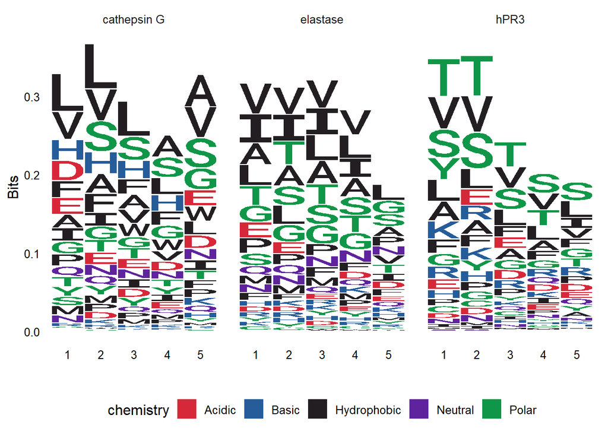

```r
ggseqlogo(meropsList, ncol = 5)
```

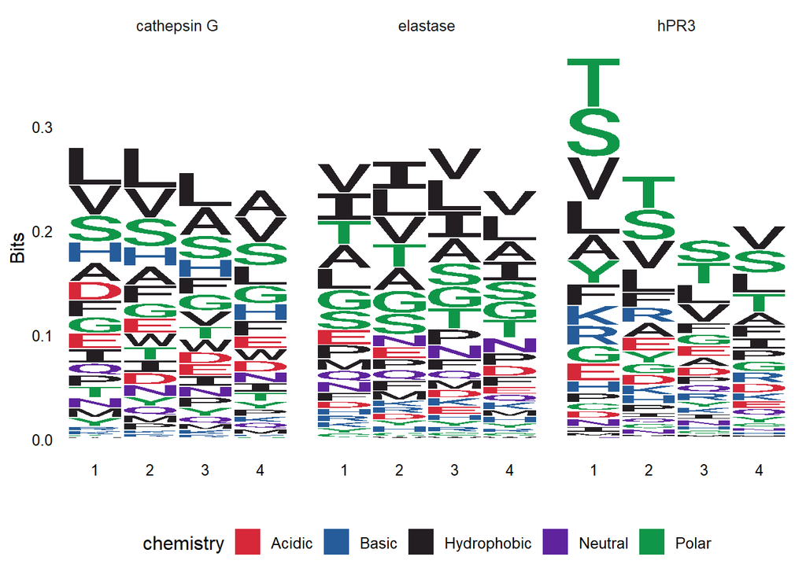

```r
ggseqlogo(meropsList_4mer, ncol = 5)
```

## Generation of 4-mer Significantly Cleaved Peptides

Significantly cleaved peptides from the phage dataset were shifted into 4-mer space, for subsequent comparison to MEROPs 4-mers.

```r
peptide_4mers <- list()
for(i in 1:3){
  seqs <- peptideList[[i]]
  temp <- c()
  for(j in 1:length(seqs)){
    temp <- c(temp, substr(seqs[j], 1, 4),substr(seqs[j], 2, 5))
  }
  peptide_4mers <- append(peptide_4mers, list(temp))
  names(peptide_4mers)[length(peptide_4mers)] <- combined[i]
}
```

## Venn Diagram Comparisons between 5-mers

To identify similarities and differences in motifs, 5-mer peptides of MEROPs substrates were compared with phage cleaved peptides using ggVennDiagram.

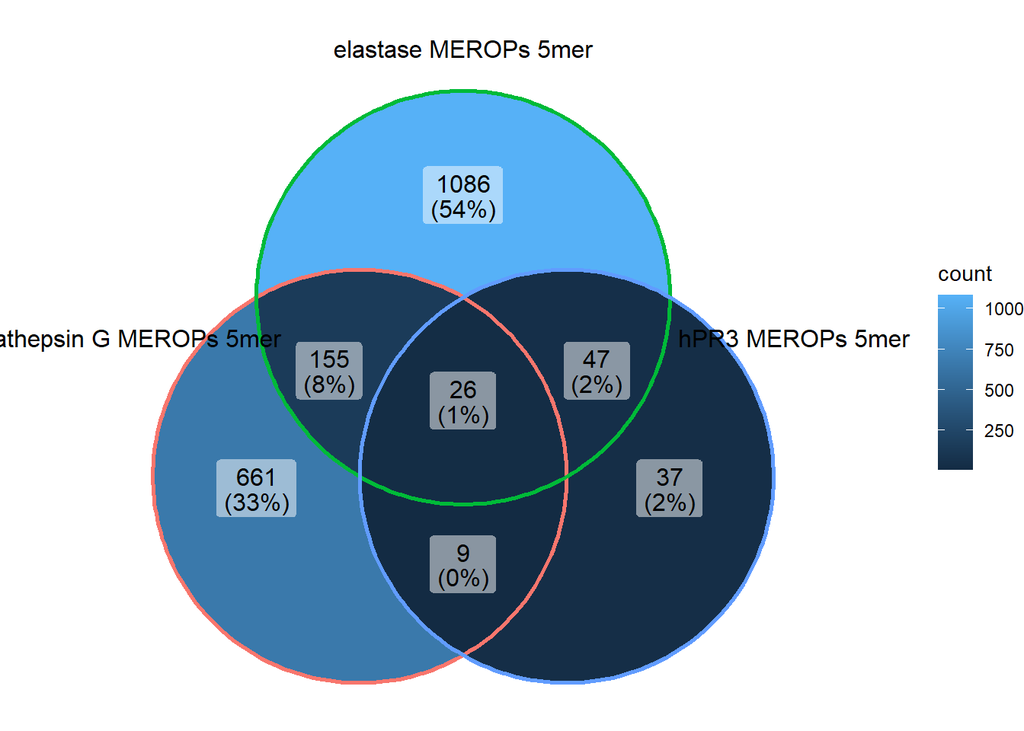

```r
venn_list <- list(`cathepsin G MEROPs 5mer` = meropsList[[1]], `elastase MEROPs 5mer`=meropsList[[2]], `hPR3 MEROPs 5mer`=meropsList[[3]])
ggVennDiagram(venn_list) + scale_x_continuous(expand = expansion(mult = .2))
```

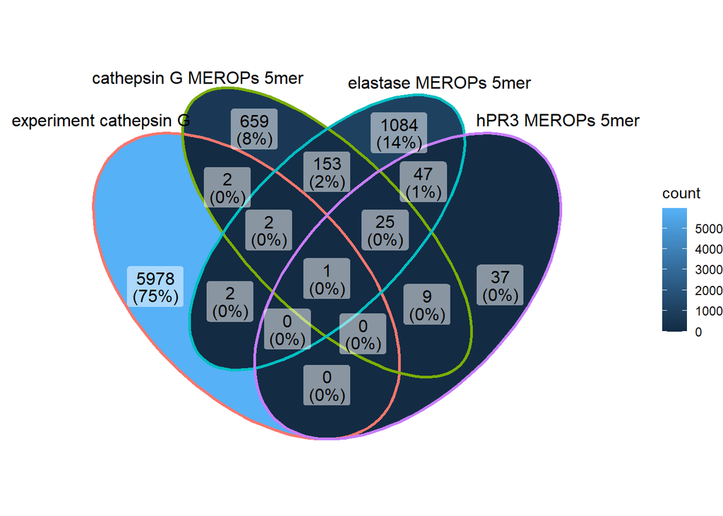

```r
venn_list <-  list(`experiment cathepsin G` = peptideList[[1]], `cathepsin G MEROPs 5mer` = meropsList[[1]],`elastase MEROPs 5mer`=meropsList[[2]], `hPR3 MEROPs 5mer`=meropsList[[3]])
ggVennDiagram(venn_list) + scale_x_continuous(expand = expansion(mult = .2))
```

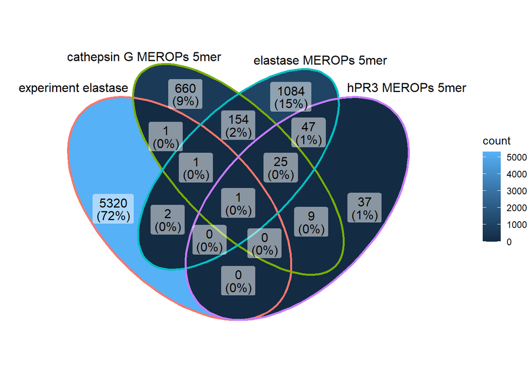

```r
venn_list <-  list(`experiment elastase`= peptideList[[2]], `cathepsin G MEROPs 5mer` = meropsList[[1]],`elastase MEROPs 5mer`=meropsList[[2]], `hPR3 MEROPs 5mer`=meropsList[[3]])
ggVennDiagram(venn_list) + scale_x_continuous(expand = expansion(mult = .2))
```

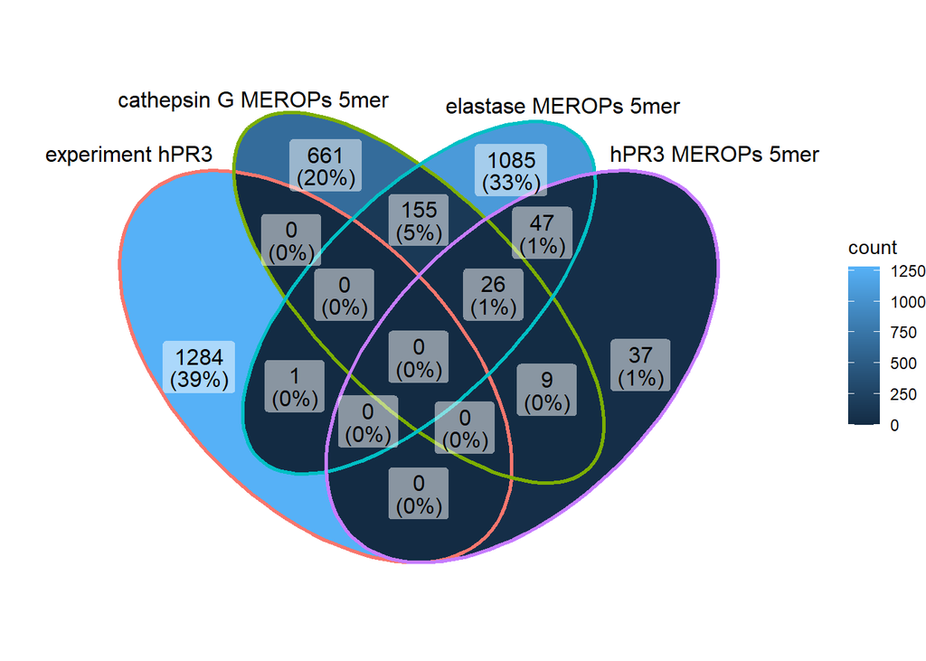

```r
venn_list <-  list(`experiment hPR3` = peptideList[[3]], `cathepsin G MEROPs 5mer` = meropsList[[1]],`elastase MEROPs 5mer`=meropsList[[2]], `hPR3 MEROPs 5mer`=meropsList[[3]])
ggVennDiagram(venn_list) + scale_x_continuous(expand = expansion(mult = .2))
```